# MD 7 demo

2022-11-03

```r
library(tidyverse)
library(toRvik)
library(moderndive)
theme_set(theme_minimal())
```

Get and wrangle data to see trends in three-point attempts.

```r
three_trend <-
  bart_team_box() |>
  group_by(year) |>
  summarize(tpa = sum(tpa),
            fga = sum(fga)) |>
  mutate(three_pct = (tpa/fga) * 100 ) |>
  select(year, three_pct) |>
  filter(year < 2022)
```

Plot.

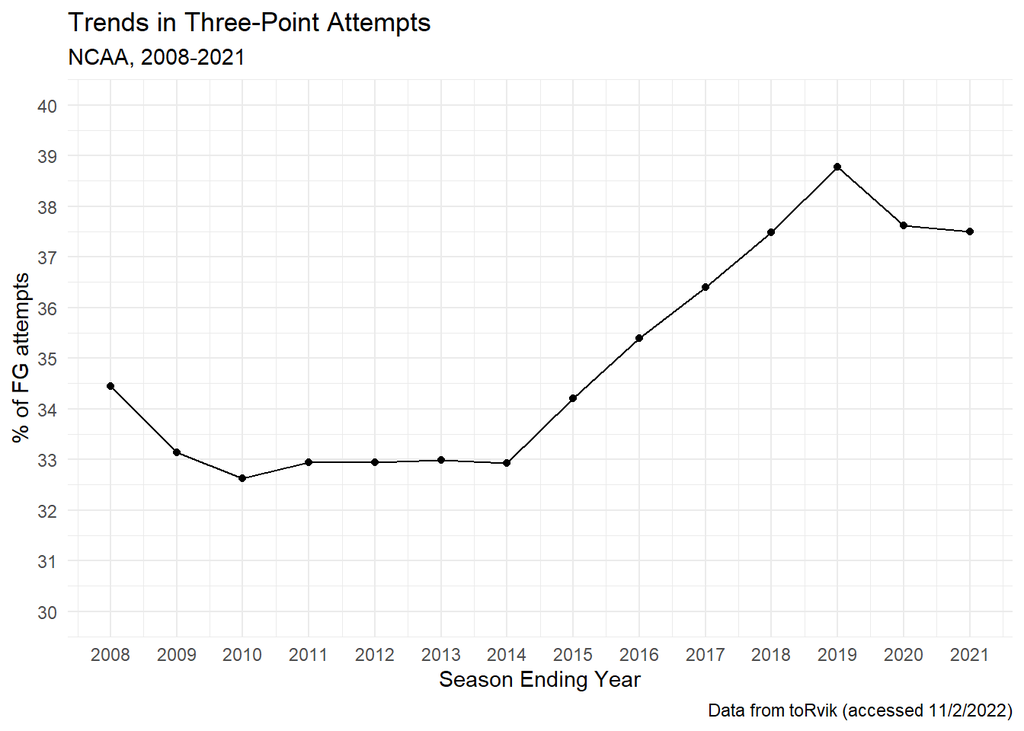

```r
ggplot(three_trend,
       aes(x = year,
           y = three_pct)) +
  geom_point() +
  geom_line() +
  scale_y_continuous(limits = c(30, 40),
                     breaks = 30:40) +
  scale_x_continuous(breaks = 2008:2021) +
  labs(title = "Trends in Three-Point Attempts",
       subtitle = "NCAA, 2008-2021",
       y = "% of FG attempts",
       x = "Season Ending Year",
       caption = "Data from toRvik (accessed 11/2/2022)")
```

Let’s pretend we don’t know the info for the 2021-2022 season. We want to know if the slight downward trend in three-point attempts continued or whether it was just a short-term aberration.

```r
shots_2022 <-
  bart_team_box(year = 2022) |>
  select(tpa, fga) |>
  summarize(tpa = sum(tpa),
            fga = sum(fga),
            three_pct = (tpa/fga)*100 )
shots_2022
```

```
## # A tibble: 1 × 3
##      tpa    fga three_pct
##    <int>  <int>     <dbl>
## 1 262022 692254      37.9
```

Let’s create a stylized dataset that has all the shots from 2021-22. Don’t worry about the details.

```r
set.seed(123)
all_shots <- tibble(
  three = c(rep(0, 430232),        # all the twos
            rep(1, 262022)),       # all the threes
  random = runif(692254, 0, 1)) |> # random for sorting
  arrange(random) |>
  select(-random)

head(all_shots, 10)
```

```
## # A tibble: 10 × 1
##    three
##    <dbl>
##  1     0
##  2     0
##  3     1
##  4     0
##  5     1
##  6     0
##  7     0
##  8     0
##  9     1
## 10     0
```

What if we tried to figure this out by watching 100 shots and seeing if we could discern a pattern. (Try this multiple times and you will get a different answer each time.)

```r
all_shots |>
  sample_n(size = 100) |>  # keep only 100 random shots
  pull(three) |>          # keep the column with the 100 0/1s
  mean()                  # take the mean
```

```
## [1] 0.42
```

### sample of 120

Let’s say it’s early in the season and sports journalists want to write a story about this. What if 50 random journalists tried to guess after watching 120 shots each? (That’s the number of shots in a typical game.)

```r
scouts120 <-
  all_shots |>
  rep_sample_n(size = 120,
               reps = 50) |>
  group_by(replicate) |>
  summarize(prop_threes = mean(three))

scouts120
```

```
## # A tibble: 50 × 2
##    replicate prop_threes
##        <int>       <dbl>
##  1         1       0.358
##  2         2       0.392
##  3         3       0.417
##  4         4       0.442
##  5         5       0.375
##  6         6       0.408
##  7         7       0.367
##  8         8       0.35
##  9         9       0.35
## 10        10       0.408
## # … with 40 more rows
```

Let’s visualize what all the different journalists saw.

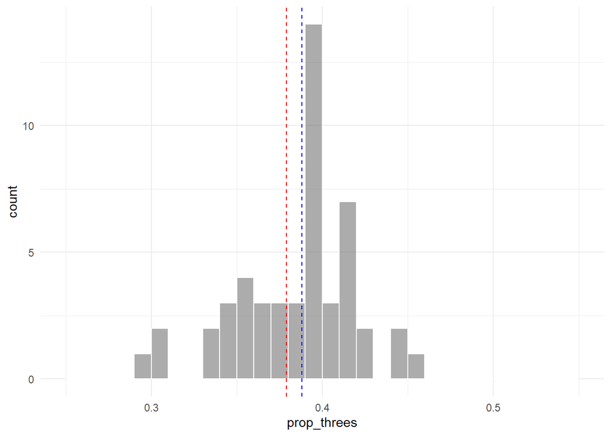

```r
ggplot(scouts120,
       aes(x = prop_threes)) +
  geom_histogram(boundary = .4,
                 binwidth = .01,
                 color = "white",
                 alpha = .5) +
  geom_vline(xintercept = c(.379, .388) , # adding the "peak" percentage line
             color = c("red", "blue"),
             linetype = "dashed") +
  scale_x_continuous(limits = c(.25,.55))
```

### sample of 500

What if they waited until they had seen 500 shots?

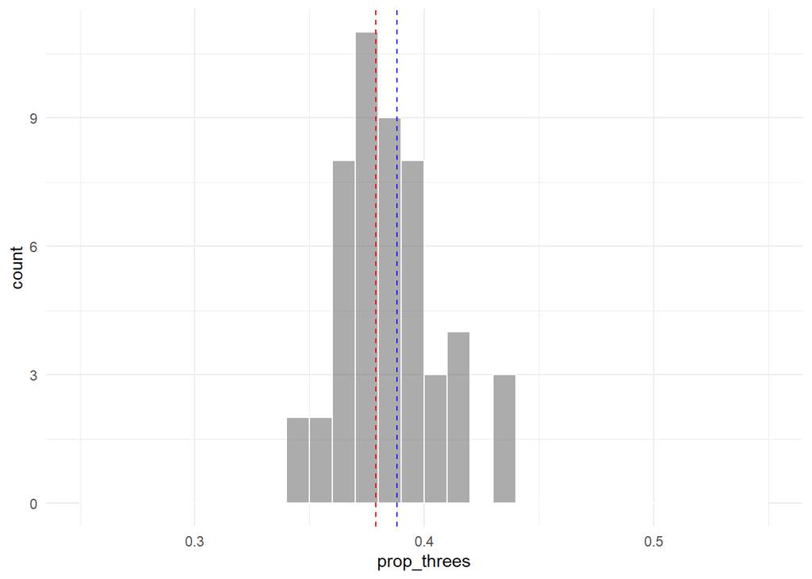

```r
scouts500 <-
  all_shots |>
  rep_sample_n(size = 500,
               reps = 50) |>
  group_by(replicate) |>
  summarize(prop_threes = mean(three))

ggplot(scouts500,
       aes(x = prop_threes)) +
  geom_histogram(boundary = .4,
                 binwidth = .01,
                 color = "white",
                 alpha = .5) +
  geom_vline(xintercept = c(.379, .388) , # adding the "peak" percentage line
             color = c("red", "blue"),
             linetype = "dashed") +
  scale_x_continuous(limits = c(.25,.55))
```

### sample of 1000

What if they waited until they had seen 1000 shots?

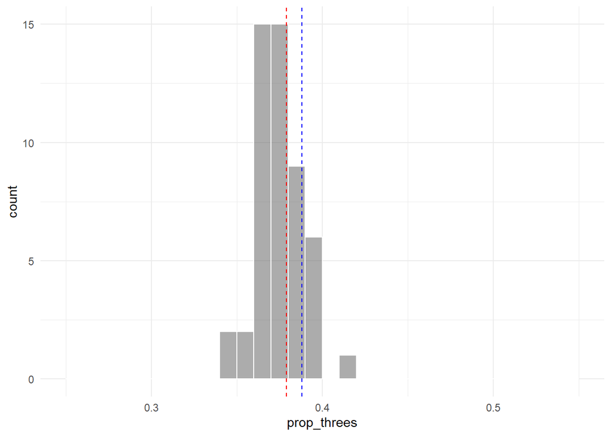

```r
scouts1000 <-
  all_shots |>
  rep_sample_n(size = 1000,
               reps = 50) |>
  group_by(replicate) |>
  summarize(prop_threes = mean(three))

ggplot(scouts1000,
       aes(x = prop_threes)) +
  geom_histogram(boundary = .4,
                 binwidth = .01,
                 color = "white",
                 alpha = .5) +
  geom_vline(xintercept = c(.379, .388) , # adding the "peak" percentage line
             color = c("red", "blue"),
             linetype = "dashed") +
  scale_x_continuous(limits = c(.25,.55))
```

### sample of 20,000

What if they waited until they had seen 20,000 shots? I’m adding a line for last season too so we can see when we get confident enough to say if this year is any different from last year or the peak.

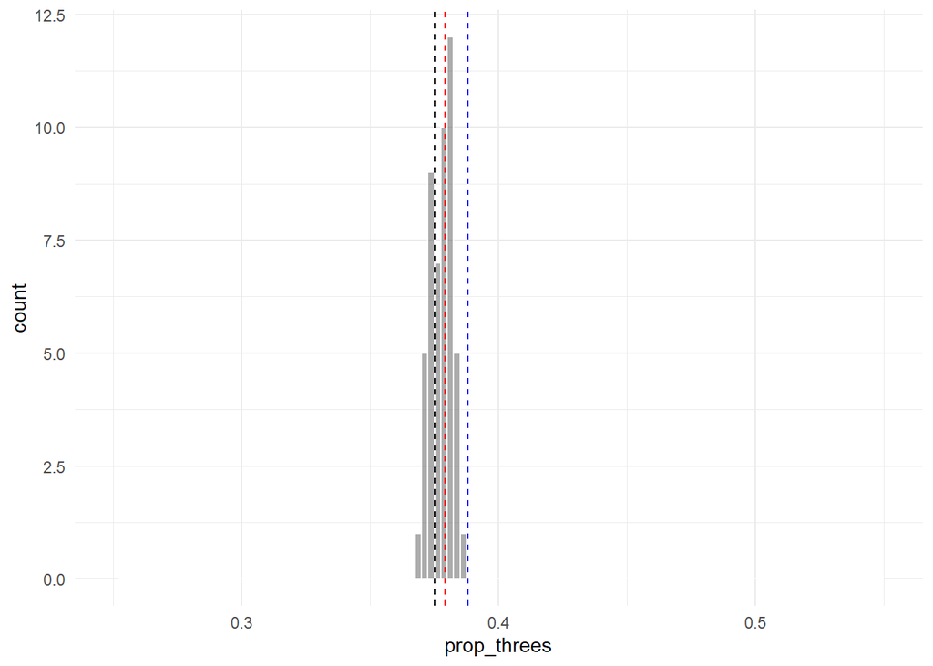

```r
scouts20000 <-
  all_shots |>
  rep_sample_n(size = 20000,
               reps = 50) |>
  group_by(replicate) |>
  summarize(prop_threes = mean(three))

ggplot(scouts20000,
       aes(x = prop_threes)) +
  geom_histogram(boundary = .4,
                 binwidth = .0025,  # make the bars skinnier for higher resolution
                 color = "white",
                 alpha = .5) +
  geom_vline(xintercept = c(.379, .388, .375) , # true, peak (2019), 2021
             color = c("red", "blue", "black"),
             linetype = "dashed") +
  scale_x_continuous(limits = c(.25,.55))
```

This is hard to see so let’s zoom in.

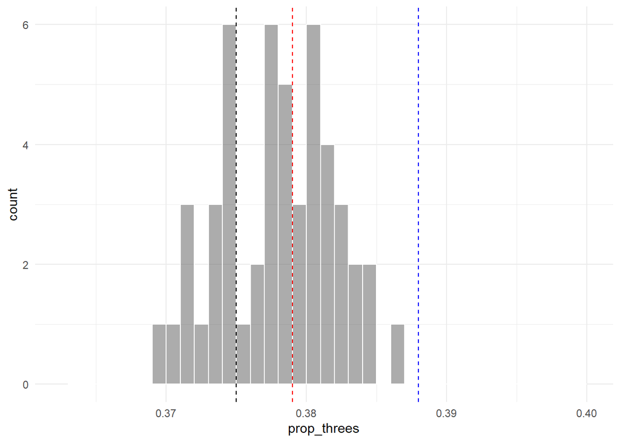

```r
ggplot(scouts20000,
       aes(x = prop_threes)) +
  geom_histogram(boundary = .4,
                 binwidth = .001,  # make the bars skinnier for higher resolution
                 color = "white",
                 alpha = .5) +
  geom_vline(xintercept = c(.379, .388, .375) , # true, peak (2019), 2021
             color = c("red", "blue", "black"),
             linetype = "dashed") +
  scale_x_continuous(limits = c(.3625,.40))
```

### sample of 80,000

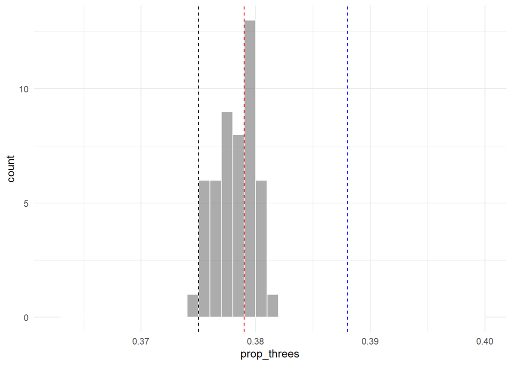

```r
scouts80000 <-
  all_shots |>
  rep_sample_n(size = 80000,
               reps = 50) |>
  group_by(replicate) |>
  summarize(prop_threes = mean(three))

ggplot(scouts80000,
       aes(x = prop_threes)) +
  geom_histogram(boundary = .4,
                 binwidth = .001,  # make the bars skinnier for higher resolution
                 color = "white",
                 alpha = .5) +
  geom_vline(xintercept = c(.379, .388, .375) , # true, peak (2019), 2021
             color = c("red", "blue", "black"),
             linetype = "dashed") +
  scale_x_continuous(limits = c(.3625,.40))
```